# Tidyverse Presentation Exercises Solutions

Shelby Smith

10/25/2020

## `ggplot2` Exercises

```r
library(dslabs)
head(gapminder)
```

```
##               country year infant_mortality life_expectancy fertility
## 1             Albania 1960           115.40           62.87      6.19
## 2             Algeria 1960           148.20           47.50      7.65
## 3              Angola 1960           208.00           35.98      7.32
## 4 Antigua and Barbuda 1960               NA           62.97      4.43
## 5           Argentina 1960            59.87           65.39      3.11
## 6             Armenia 1960               NA           66.86      4.55
##   population          gdp continent          region
## 1    1636054           NA    Europe Southern Europe
## 2   11124892  13828152297    Africa Northern Africa
## 3    5270844           NA    Africa   Middle Africa
## 4      54681           NA  Americas       Caribbean
## 5   20619075 108322326649  Americas   South America
## 6    1867396           NA      Asia    Western Asia
```

1. To view the distribution of discrete variables like `continent`, try generating a bar chart that counts the number of observations of each `continent` in the dataset. Once you have this generated, try setting `fill = continent` within the global aesthetics & see how your visualization changes.

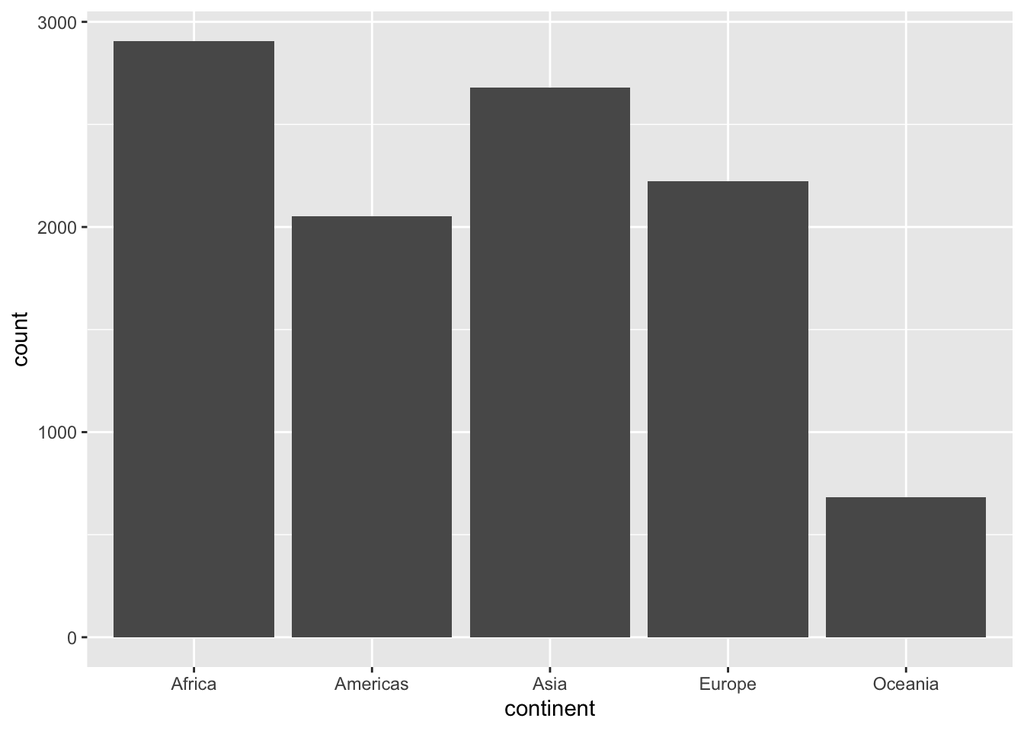

```r
ggplot(gapminder, aes(x = continent)) +
  geom_bar()
```

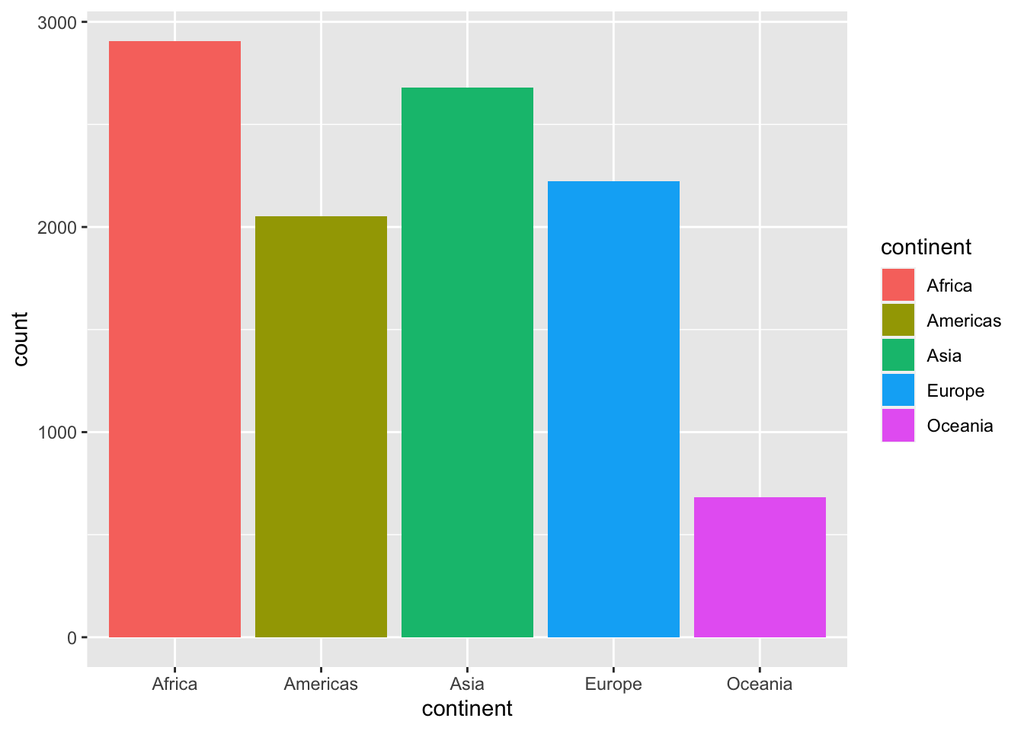

```r
ggplot(gapminder, aes(x = continent, fill = continent)) +
  geom_bar()
```

2. What is the distribution of `life_expectancy` over the whole data set? (Hint: use the `geom_density` layer, after mapping the x-variable to `life_expectancy`)

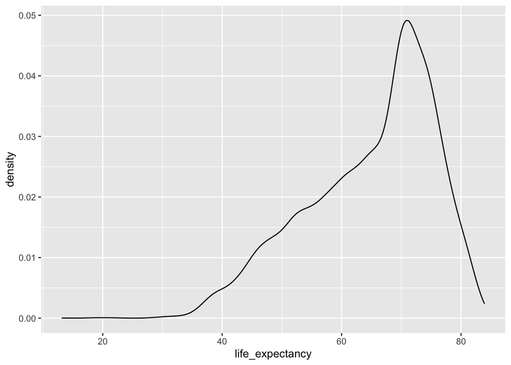

```r
ggplot(gapminder, aes(x = life_expectancy)) +
  geom_density()
```

3. Can we group this by continent? Try setting “fill = `continent`” after “x = `life_expectancy`”. (Hint: `geom_density(alpha = 0.5)` makes the density distributions transparent).

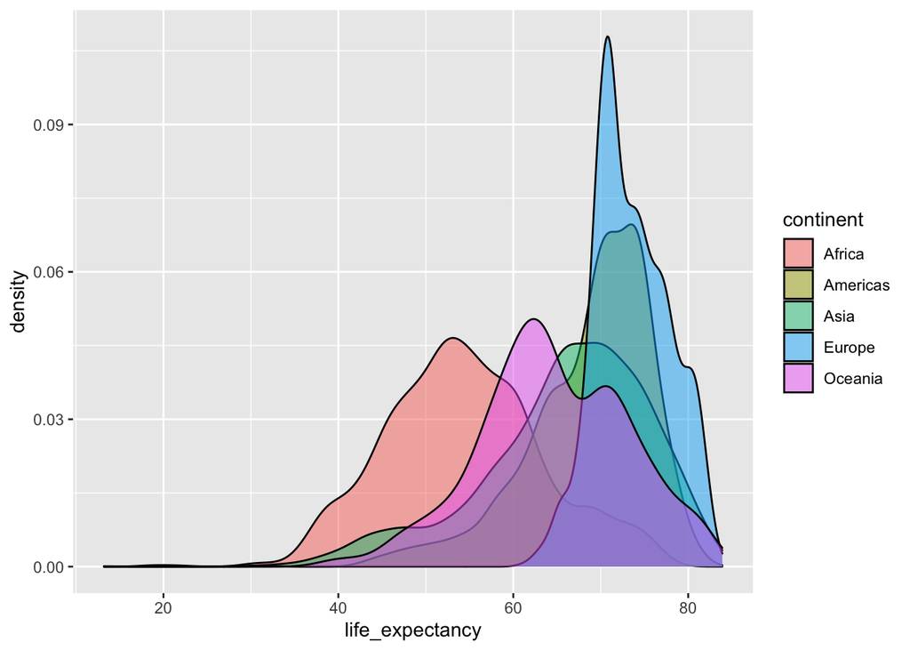

```r
ggplot(gapminder, aes(x = life_expectancy, fill = continent)) +
  geom_density(alpha = 0.5)
```

4. How has `life_expectancy` changed over the years, `year`, by `continent`? Try fitting this first with a scatter plot, and then with a ‘lm’ smoother to see two different ways of visualizing this. (Hint: one is much simpler on the eye!)

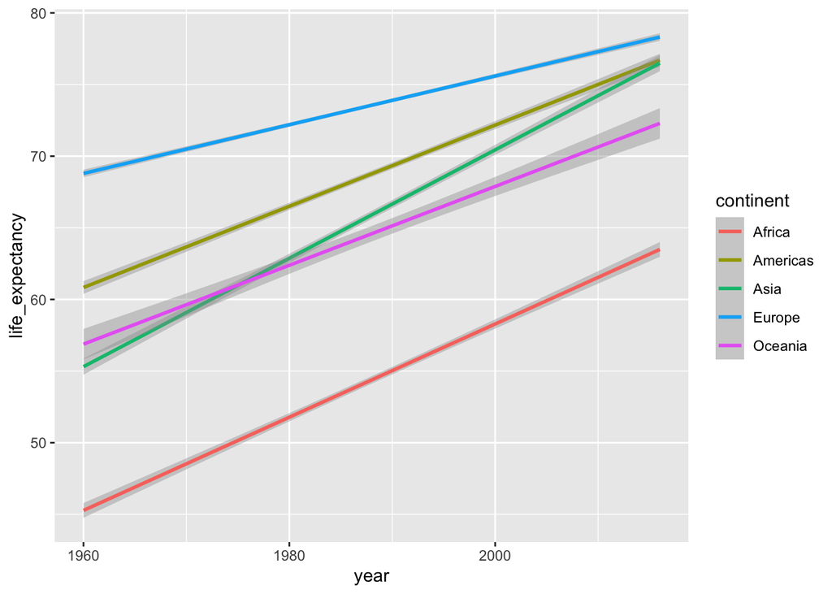

```r
ggplot(data = gapminder) +
  geom_smooth(mapping = aes(x = year, y = life_expectancy, color = continent), method = 'lm')
```

## Data Manipulation Exercises

1. Extract data from the *gapminder* dataset that contains the following information:
- Country: Belize
- Year: 1990
- Life_expectancy
- Population
- Continent

```r
gapminder %>% filter(country == c('Belize')) %>%
  filter(year == 1990) %>%
  select(country, year, life_expectancy, population, continent)
```

```
##   country year life_expectancy population continent
## 1  Belize 1990            71.4     187552  Americas
```

2. Maybe we’re interested in calculating the gross domestic product per capita. Use the mutate function & write an expression to calculate this, and create a new column in the dataframe. (Hint: gdp / population)

```r
gapminder %>% mutate(gdp_percap = gdp / population) %>%
  select(country, year, gdp, population, gdp_percap) %>%
  head
```

```
##               country year          gdp population gdp_percap
## 1             Albania 1960           NA    1636054         NA
## 2             Algeria 1960  13828152297   11124892   1242.992
## 3              Angola 1960           NA    5270844         NA
## 4 Antigua and Barbuda 1960           NA      54681         NA
## 5           Argentina 1960 108322326649   20619075   5253.501
## 6             Armenia 1960           NA    1867396         NA
```

3. Build on your code from question 2, and find out the top 3 GDP per capita in each continent (Hint: use %>% head(3) at the end to only select the top 3).

```r
# Descending gdp_percap for Africa
gapminder %>% mutate(gdp_percap = gdp / population) %>%
  filter(continent == 'Africa') %>%
  arrange(desc(gdp_percap)) %>%
  select(continent, country, year, population, gdp, gdp_percap) %>%
  head(3)
```

```
##   continent           country year population        gdp gdp_percap
## 1    Africa Equatorial Guinea 2011     750918 6403432391   8527.472
## 2    Africa Equatorial Guinea 2009     707155 6024744206   8519.694
## 3    Africa        Seychelles 2011      93810  798003690   8506.595
```

```r
gapminder %>% mutate(gdp_percap = gdp / population) %>%
  filter(continent == 'Europe') %>%
  arrange(desc(gdp_percap)) %>%
  select(continent, country, year, population, gdp, gdp_percap) %>%
  head(3)
```

```
##   continent    country year population         gdp gdp_percap
## 1    Europe Luxembourg 2007     474705 27066319405   57017.14
## 2    Europe Luxembourg 2008     485079 27270323848   56218.31
## 3    Europe Luxembourg 2006     465546 25381346505   54519.52
```

```r
# To be continued for all countries!
```

### Challenge Exercises using the NYC Flights Data

```r
#install.packages('nycflights13')
library(nycflights13)
data(flights)

data(airlines)

flights_carrier <- flights %>%
  inner_join(airlines, by=c('carrier'='carrier'))

glimpse(flights_carrier)
```

```
## Rows: 336,776
## Columns: 20
## $ year           <int> 2013, 2013, 2013, 2013, 2013, 2013, 2013, 2013, 2013, …
## $ month          <int> 1, 1, 1, 1, 1, 1, 1, 1, 1, 1, 1, 1, 1, 1, 1, 1, 1, 1, …
## $ day            <int> 1, 1, 1, 1, 1, 1, 1, 1, 1, 1, 1, 1, 1, 1, 1, 1, 1, 1, …
## $ dep_time       <int> 517, 533, 542, 544, 554, 554, 555, 557, 557, 558, 558,…
## $ sched_dep_time <int> 515, 529, 540, 545, 600, 558, 600, 600, 600, 600, 600,…
## $ dep_delay      <dbl> 2, 4, 2, -1, -6, -4, -5, -3, -3, -2, -2, -2, -2, -2, -…
## $ arr_time       <int> 830, 850, 923, 1004, 812, 740, 913, 709, 838, 753, 849…
## $ sched_arr_time <int> 819, 830, 850, 1022, 837, 728, 854, 723, 846, 745, 851…
## $ arr_delay      <dbl> 11, 20, 33, -18, -25, 12, 19, -14, -8, 8, -2, -3, 7, -…
## $ carrier        <chr> "UA", "UA", "AA", "B6", "DL", "UA", "B6", "EV", "B6", …
## $ flight         <int> 1545, 1714, 1141, 725, 461, 1696, 507, 5708, 79, 301, …
## $ tailnum        <chr> "N14228", "N24211", "N619AA", "N804JB", "N668DN", "N39…
## $ origin         <chr> "EWR", "LGA", "JFK", "JFK", "LGA", "EWR", "EWR", "LGA"…
## $ dest           <chr> "IAH", "IAH", "MIA", "BQN", "ATL", "ORD", "FLL", "IAD"…
## $ air_time       <dbl> 227, 227, 160, 183, 116, 150, 158, 53, 140, 138, 149, …
## $ distance       <dbl> 1400, 1416, 1089, 1576, 762, 719, 1065, 229, 944, 733,…
## $ hour           <dbl> 5, 5, 5, 5, 6, 5, 6, 6, 6, 6, 6, 6, 6, 6, 6, 5, 6, 6, …
## $ minute         <dbl> 15, 29, 40, 45, 0, 58, 0, 0, 0, 0, 0, 0, 0, 0, 0, 59, …
## $ time_hour      <dttm> 2013-01-01 05:00:00, 2013-01-01 05:00:00, 2013-01-01 …
## $ name           <chr> "United Air Lines Inc.", "United Air Lines Inc.", "Ame…
```

1. Using the `flights_carrier` dataset, create a new data set, `flights2` that contains the carrier name, year, month, day, departure delay, arrival delay, origin airport, destination airport, and flight number.

```r
flights2 <- select(flights_carrier, carrier, year, month, day, dep_delay, arr_delay, origin, dest, flight)
head(flights2)
```

```
## # A tibble: 6 x 9
##   carrier  year month   day dep_delay arr_delay origin dest  flight
##   <chr>   <int> <int> <int>     <dbl>     <dbl> <chr>  <chr>  <int>
## 1 UA       2013     1     1         2        11 EWR    IAH     1545
## 2 UA       2013     1     1         4        20 LGA    IAH     1714
## 3 AA       2013     1     1         2        33 JFK    MIA     1141
## 4 B6       2013     1     1        -1       -18 JFK    BQN      725
## 5 DL       2013     1     1        -6       -25 LGA    ATL      461
## 6 UA       2013     1     1        -4        12 EWR    ORD     1696
```

2. How many unique flight routes does American Airlines Inc. run departing from the New York area? (Hint: use the n_distinct() command within `summarise`)

```r
flights2 %>% filter(carrier == 'AA') %>% summarize(n_distinct(flight))
```

```
## # A tibble: 1 x 1
##   `n_distinct(flight)`
##                  <int>
## 1                  220
```

3. How many unique flight routes does American Airlines Inc. run from each of the three area airports?

```r
flights2 %>% filter(carrier == 'AA') %>% group_by(origin) %>% summarize(n_distinct(flight))
```

```
## # A tibble: 3 x 2
##   origin `n_distinct(flight)`
##   <chr>                 <int>
## 1 EWR                      30
## 2 JFK                      92
## 3 LGA                     102
```

```r
# Mean for each origin
flights2 %>% filter(carrier == 'UA') %>% filter(dep_delay != 'NA') %>% group_by(origin) %>% summarize(mean=mean(dep_delay))
```

```
## # A tibble: 3 x 2
##   origin  mean
##   <chr>  <dbl>
## 1 EWR     12.5
## 2 JFK      7.9
## 3 LGA     12.1
```

```r
#Mean for any New York airport
flights2 %>% filter(carrier == 'UA') %>% filter(dep_delay != 'NA') %>% summarize(mean=mean(dep_delay))
```

```
## # A tibble: 1 x 1
##    mean
##   <dbl>
## 1  12.1
```